# 6_1_E_SES_Exercise

```r
library(fpp3)
```

# SES Exercise

### 1. Select the data corresponding to Argentina from the dataset `global economy`. In particular, we are going to focus on its exports, so you may extract them as well. Produce a timeplot of the exports with mayor ticks every ten years and minor ticks every five years

```r
arg_exports <- global_economy %>%
                  filter(Country == "Argentina") %>%
                  select(Year, Exports)

arg_exports
```

```
# A tsibble: 58 x 2 [1Y]
    Year Exports
   <dbl>   <dbl>
 1  1960    7.60
 2  1961    5.99
 3  1962    4.69
 4  1963    7.89
 5  1964    5.56
 6  1965    6.23
 7  1966    6.65
 8  1967    7.50
 9  1968    6.48
10  1969    6.40
# ℹ 48 more rows
```

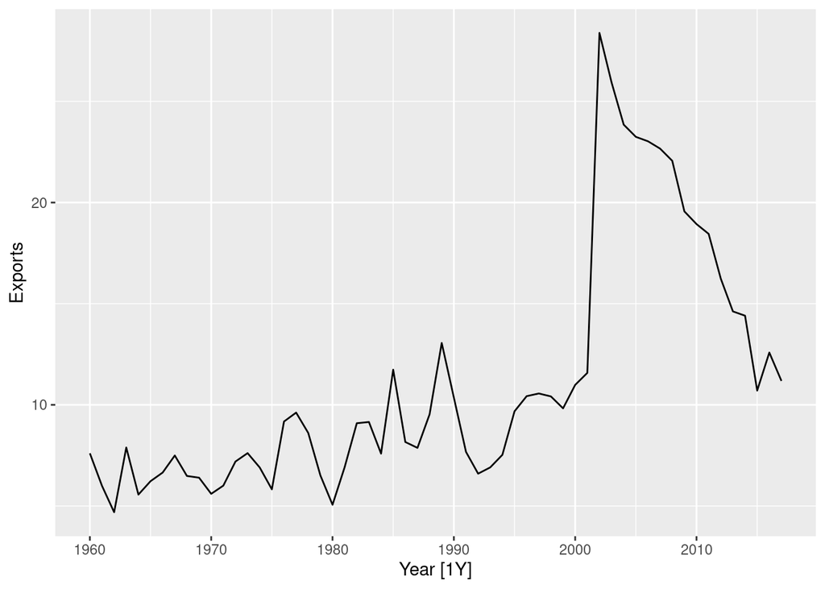

```r
min_year <- min(arg_exports$Year)
max_year <- max(arg_exports$Year)
minor_ticks_seq <- seq(min_year, max_year, by=5)
major_ticks_seq <- seq(min_year, max_year, by=10)

arg_exports %>%

  autoplot(Exports) +

  # We use scale_x_continuous
  # because Year is of type double
  # with type "double" we need to specify
  # the sequences.
  scale_x_continuous(
    breaks = major_ticks_seq,
    minor_breaks = minor_ticks_seq
  )
```

### 2. Fit a simple exponential smoothing method `ETS(A,N,N)` to the series. Plot the forecast along with the fitted values.

```r
fit <-
  arg_exports %>%
  model(
    ses_exports = ETS(Exports ~ error("A") + trend("N") + season("N"))
  )

fc <-
  fit %>%
  forecast(h=8)

fc
```

```
# A fable: 8 x 4 [1Y]
# Key:     .model [1]
  .model       Year   Exports .mean
  <chr>       <dbl>    <dist> <dbl>
1 ses_exports  2018  N(11, 8)  11.3
2 ses_exports  2019 N(11, 14)  11.3
3 ses_exports  2020 N(11, 20)  11.3
4 ses_exports  2021 N(11, 27)  11.3
5 ses_exports  2022 N(11, 33)  11.3
6 ses_exports  2023 N(11, 39)  11.3
7 ses_exports  2024 N(11, 46)  11.3
8 ses_exports  2025 N(11, 52)  11.3
```

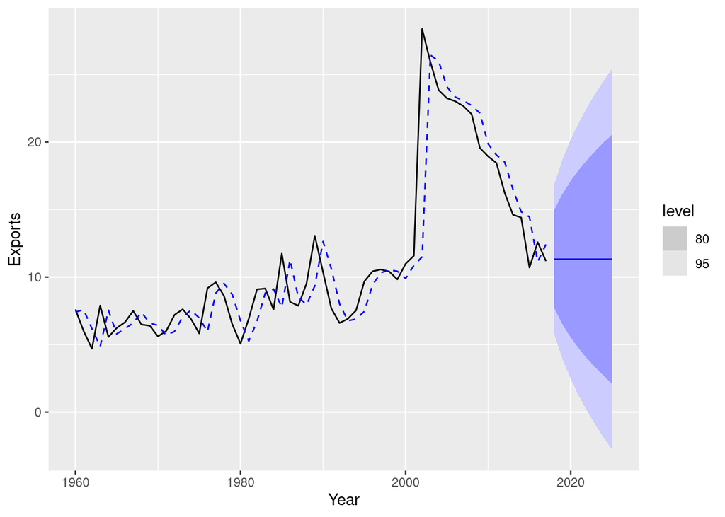

```r
fitted_vals <-
  fit %>%
  augment()

fc %>%
  autoplot(arg_exports) +
  autolayer(fitted_vals, .fitted, colour = "blue", linetype = "dashed")
```

#### * **Do you think the ETS forecast method is appropriate for this data? Why? Why not?**

```r
As explained iin the theory session, Simple Exponential Smoothing is appropriate
for data that does not have clear trend or seasonality.

The time plot reveals that this is the case, so the model seems appropriate.
```

### 3. How many parameters does the model have? Extract their values. Give an interpretation of the value of the parameter alpha.

```r
There are two parameters to every Simple Exponential Smoothing model:
alpha and the initial level l_0

We can inspect the values resulting from the minimisation of the SSE when
the model was fitted by using the function `tidy()`:
```

```r
ses_params <- tidy(fit)
ses_params
```

```
# A tibble: 2 × 3
  .model      term  estimate
  <chr>       <chr>    <dbl>
1 ses_exports alpha    0.886
2 ses_exports l[0]     7.41
```

```r
Remember these values have been chosen by the library `fable` as part of the
model fitting process. They are the values of the parameters
that minimize the SSE (Sum of Squared Errors).

The fact that alpha is roughly 0.89 means that the most recent observation
gets assigned a weight of 0.89. The remaining 0.11 percent is split in an
exponentially decreasing manner across all other observations.

Now we are going to add an additional column that computes the exact weight
assigned to each observation. This code and the corresponding equations are
explained in the theory lessons.
```

```r
# Esxtract the value of alpha
alpha <- ses_params$estimate[1]

weights <- vector("double")
for (i in seq(1:nrow(fitted_vals))){
  # Compute the weight associated to each observation
  weights[[i]] <- alpha*((1-alpha)**(i-1))
}

# Add this column to the fitted values
fitted_vals$weight = rev(weights)

# Reverse de order of the dataframe to depict it more clearly
fitted_vals <-
  fitted_vals %>% arrange(desc(Year))
fitted_vals
```

```
# A tsibble: 58 x 7 [1Y]
# Key:       .model [1]
   .model       Year Exports .fitted .resid .innov        weight
   <chr>       <dbl>   <dbl>   <dbl>  <dbl>  <dbl>         <dbl>
 1 ses_exports  2017    11.2    12.4 -1.24  -1.24  0.886
 2 ses_exports  2016    12.6    11.1  1.45   1.45  0.101
 3 ses_exports  2015    10.7    14.5 -3.75  -3.75  0.0116
 4 ses_exports  2014    14.4    14.8 -0.427 -0.427 0.00133
 5 ses_exports  2013    14.6    16.5 -1.88  -1.88  0.000152
 6 ses_exports  2012    16.2    18.5 -2.28  -2.28  0.0000174
 7 ses_exports  2011    18.4    19.0 -0.590 -0.590 0.00000199
 8 ses_exports  2010    18.9    19.9 -0.922 -0.922 0.000000228
 9 ses_exports  2009    19.6    22.1 -2.57  -2.57  0.0000000261
10 ses_exports  2008    22.1    22.7 -0.648 -0.648 0.00000000299
# ℹ 48 more rows
```

```r
The column weight contains the column associated to each specific observation to
produce the forecasts. We are finally going to compute the weight assigned to
the first three elements combined as well as the weight assigned to all elements
beyond the third
```

```r
n = 3

# Weight assigned to the first three elements
# (as a fraction of 1)
sum(fitted_vals$weight[1:n])
```

```
[1] 0.9984999
```

```r
# Weight assigned to all elements beyond the third
sum(fitted_vals$weight[(n+1):nrow(fitted_vals)])
```

```
[1] 0.001500143
```

```r
# Of course, both these things add up to 1
sum(fitted_vals$weight[1:n]) + sum(fitted_vals$weight[(n+1):nrow(fitted_vals)])
```

```
[1] 1
```

### 4. Compute the standard deviation of the residuals as (see equation in html format of the notebook). See session 6_2 for more details.

$$\begin{equation}
\hat{\sigma} = \sqrt{\frac{1}{T-K}\sum_{t=1}^T e_t^2}
\end{equation}$$

- $K$ is the number of parameters estimated in the forecasting method

### 5. Compute a 95% prediction interval for the first forecast using $\hat{y} \pm 1.96s$, where s is the standard deviation of the residuals computed in the previous point. See lesson 6_2 for further guidance.

### 6. Extract the prediction interval produced by R for the first forecast (see session 6_2). How does your prediction interval compare to that?